# Topic 4 Exercises: Classification

### Qinxi Wang

```
Topic 4 Assignment:
    Programming Assignment: 4.7.11, 4.7.13
    Theory assignment: 4.7.1, 4.7.8, 4.7.9
```

```r
library(ISLR)
#attach(Auto)
library(MASS)
library(class)
#attach(Boston)
```

#### 4.7.11

##### (a)

```r
Auto$mpg01 = ifelse(Auto$mpg > median(Auto$mpg), 1 ,0)
#Auto2 = data.frame(Auto, mpg01)
```

##### (b)

```r
names(Auto)
```

```
##  [1] "mpg"          "cylinders"    "displacement" "horsepower"
##  [5] "weight"       "acceleration" "year"         "origin"
##  [9] "name"         "mpg01"
```

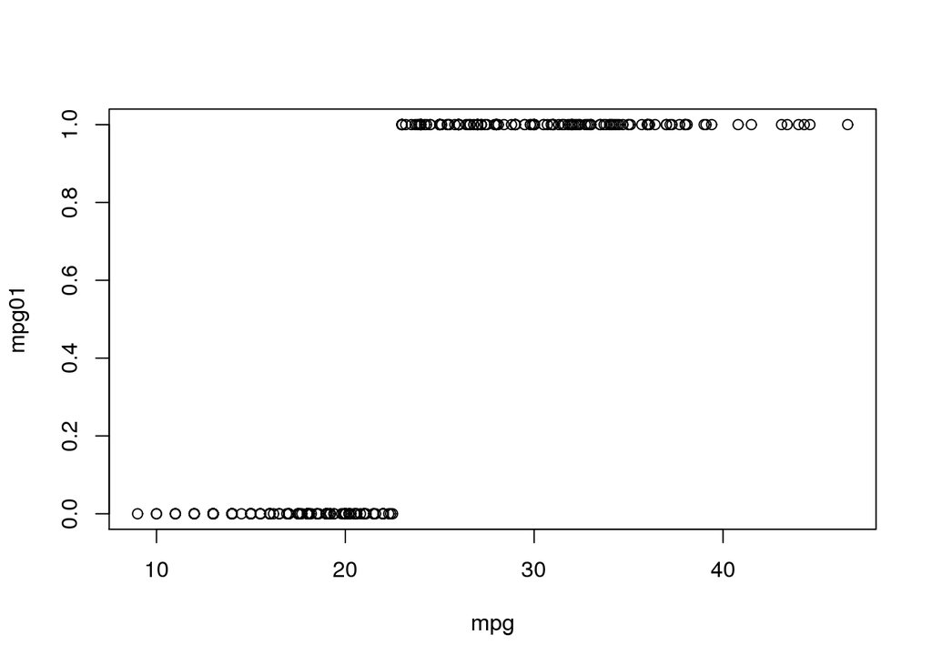

```r
# Scatterplots
plot(mpg01 ~ mpg, data = Auto)
```

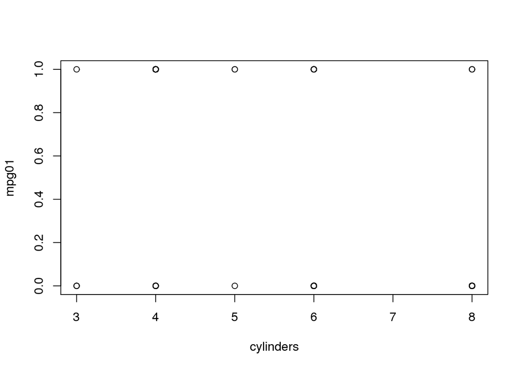

```r
plot(mpg01 ~ cylinders, data = Auto)
```

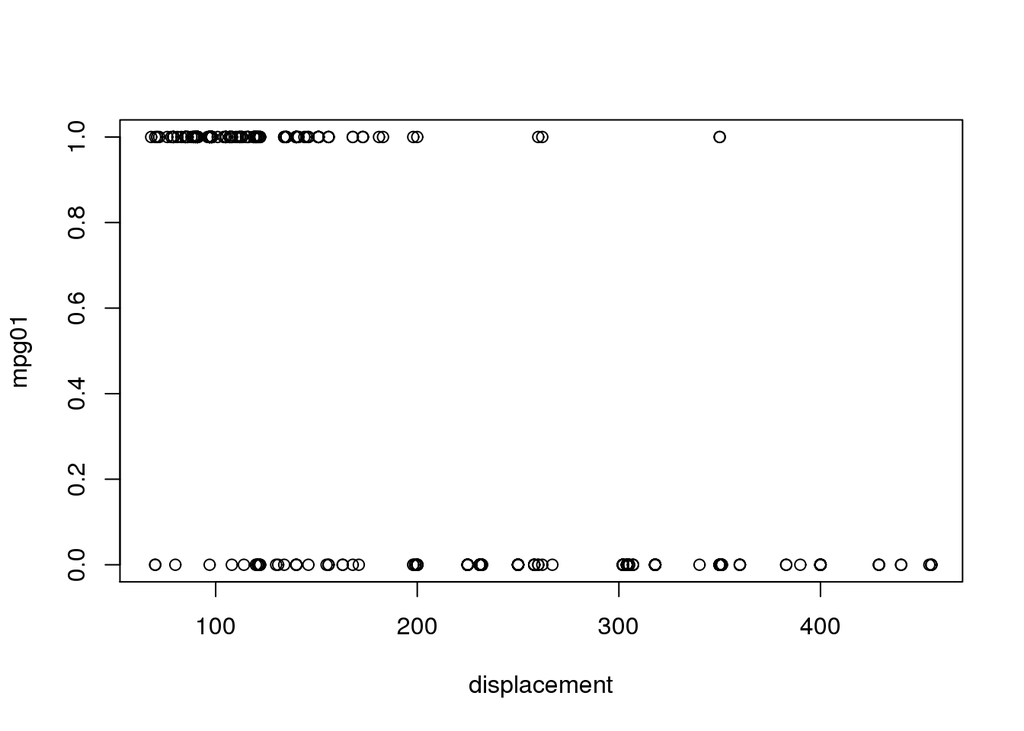

```r
plot(mpg01 ~ displacement, data = Auto)
```

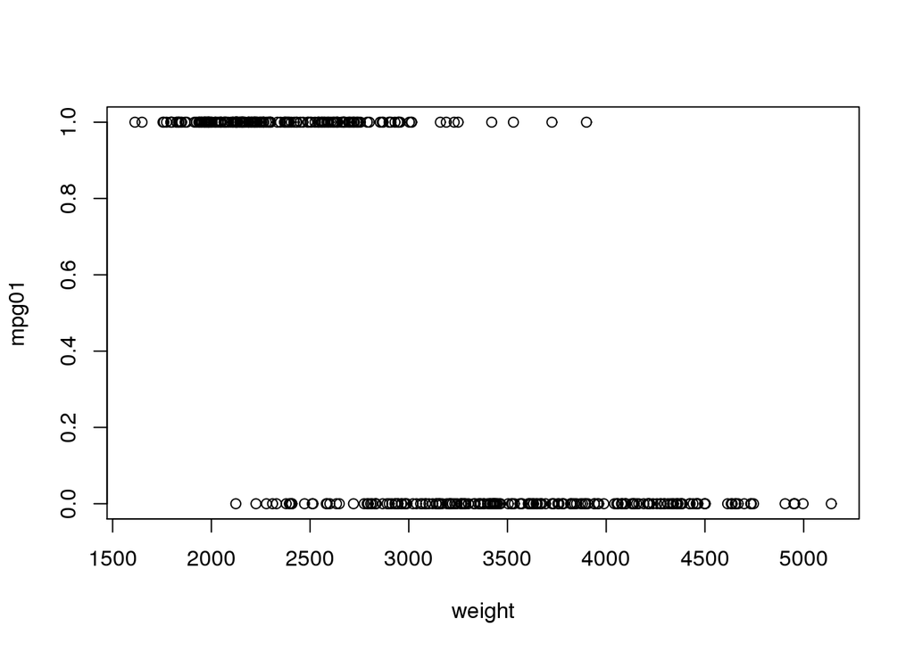

```r
plot(mpg01 ~ weight, data = Auto)
```

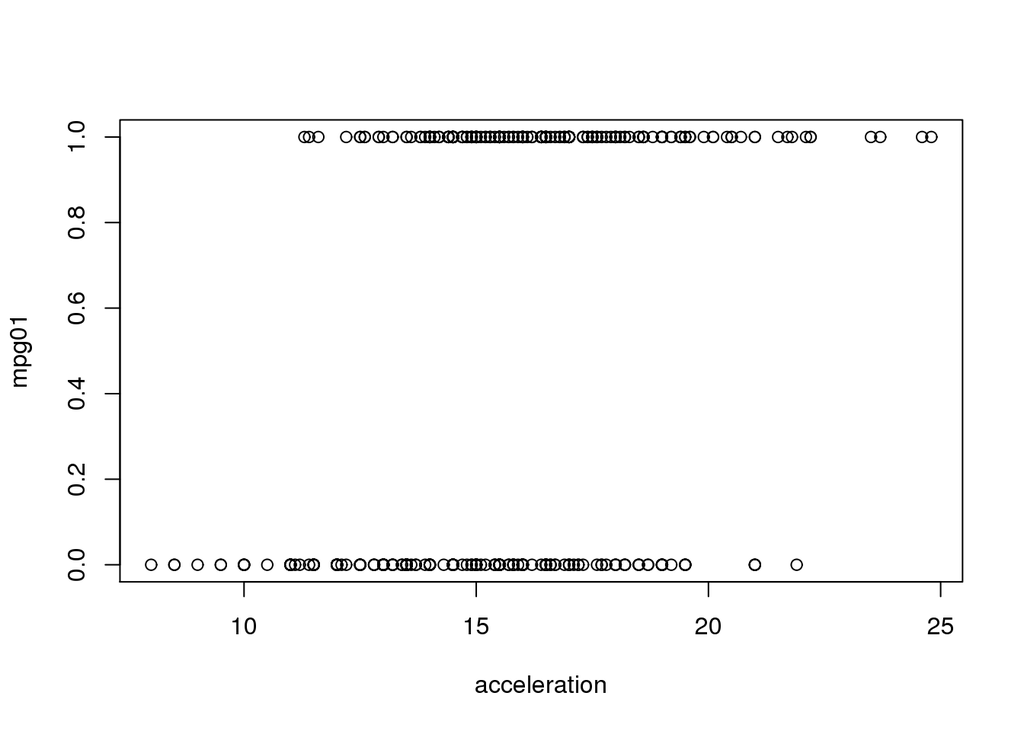

```r
plot(mpg01 ~ acceleration, data = Auto)
```

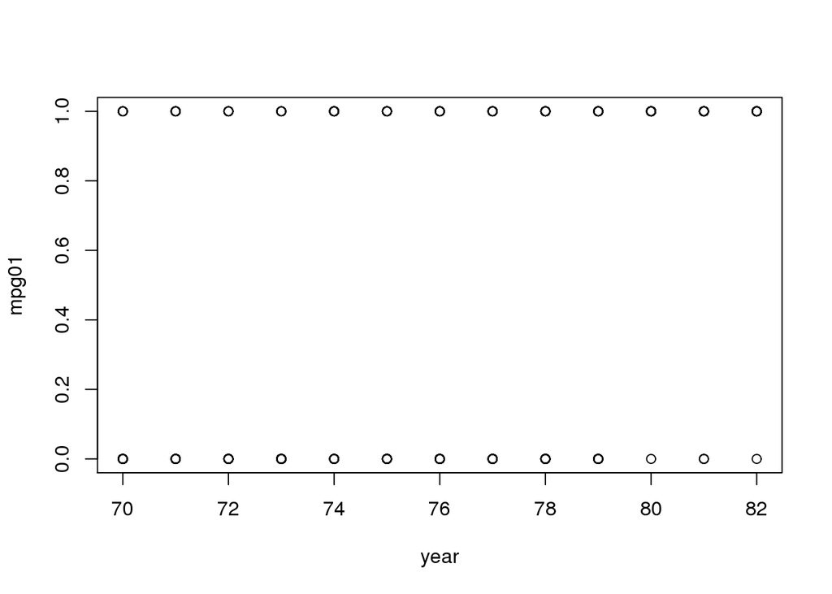

```r
plot(mpg01 ~ year, data = Auto ) #year, mpg01)
```

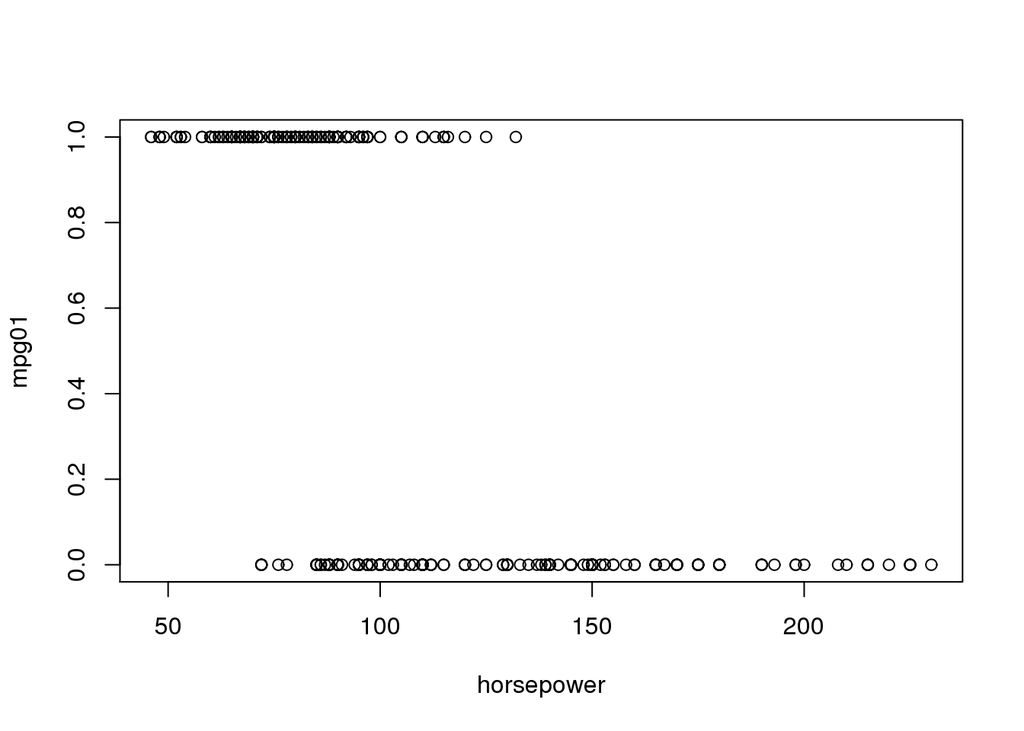

```r
plot(mpg01 ~ horsepower, data = Auto) #horsepower, mpg01)
```

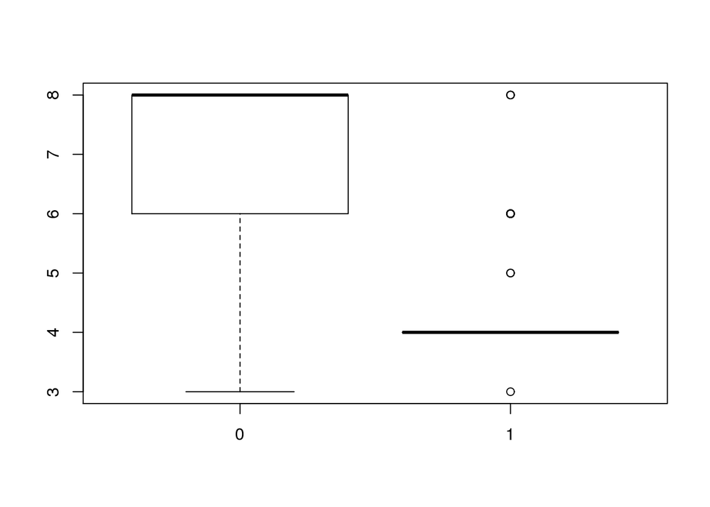

```r
#Boxplots
boxplot(cylinders ~ mpg01, data = Auto)
```

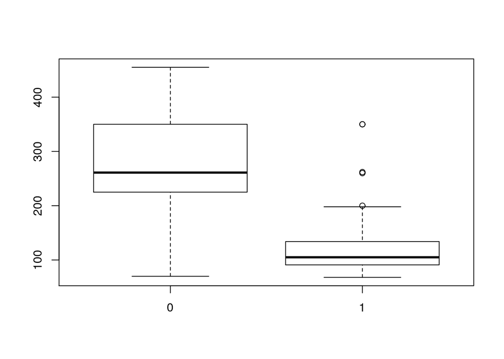

```r
boxplot(displacement ~ mpg01, data = Auto)
```

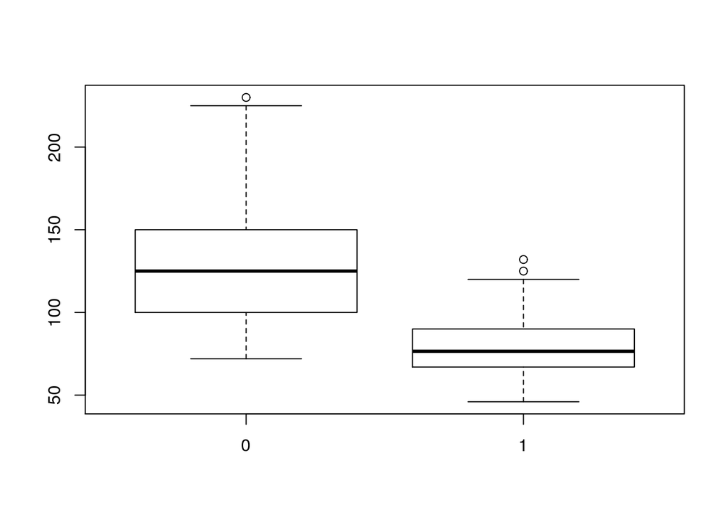

```r
boxplot(horsepower ~ mpg01, data = Auto)
```

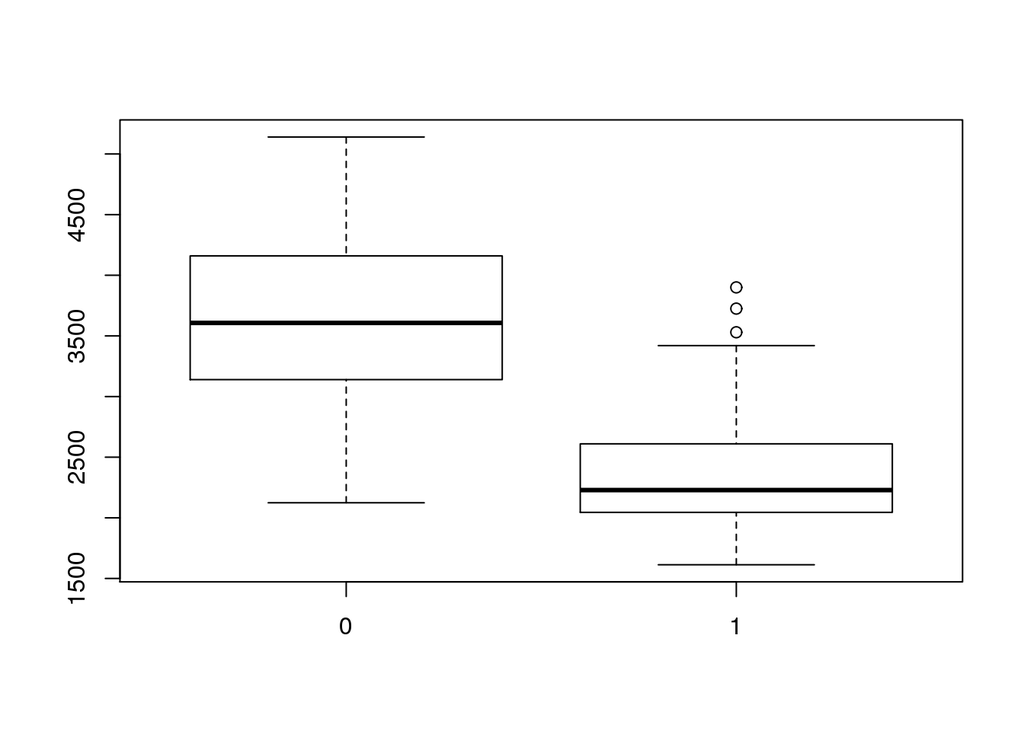

```r
boxplot(weight ~ mpg01,data = Auto)
```

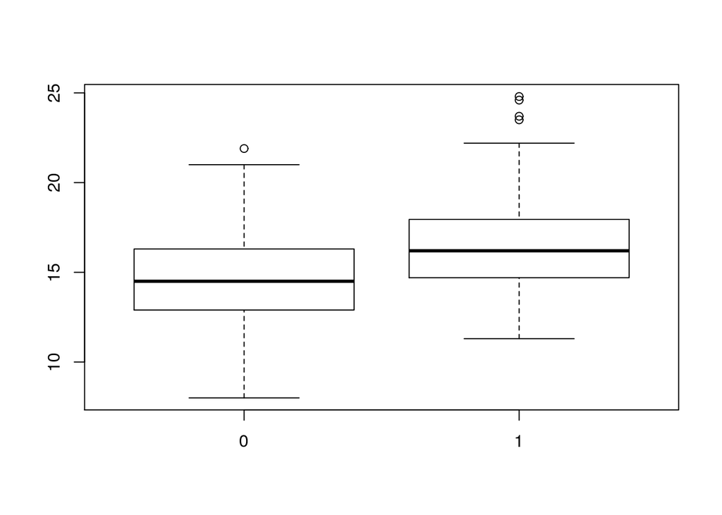

```r
boxplot(acceleration ~ mpg01, data = Auto)
```

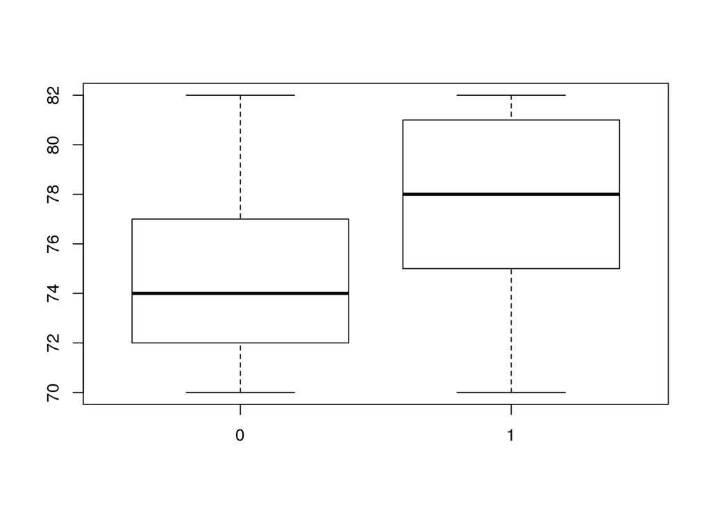

```r
boxplot(year ~ mpg01, data = Auto)
```

It appears that there exists some association between mpg01 and cylinders, horsepower, displacement, weight, and acceleration.

##### (c) & (d)

```r
k = 10
method = lda
data = Auto
response <- "mpg01"
sets = (1:nrow(data) %% k) + 1
table = list()
means = rep(0, k)
for (i in 1:k){
    For_Testing = data[sets==i,]
    For_Training = data[sets!=i,]
    Response_Test = data[[response]][sets==i]
    mod_LDA_one <- lda(mpg01 ~ cylinders + weight + displacement + horsepower + acceleration,
                       data = For_Training)
    test_LDA_one <- predict(mod_LDA_one, newdata = For_Testing)

    table[[i]] = table(test_LDA_one$class, Response_Test)
    means[i] = mean(test_LDA_one$class != Response_Test)
}
mean(means)
```

```
## [1] 0.1094872
```

The test error of the model obtained from using the five factors in b) using LDA is 10.95%.

##### (e)

```r
#QDA
k = 10
data = Auto
response <- "mpg01"
sets = (1:nrow(data) %% k) + 1
table2 = list()
means2 = rep(0, k)
for (i in 1:k){
    For_Testing = data[sets==i,]
    For_Training = data[sets!=i,]
    Response_Test = data[[response]][sets==i]
    mod_QDA_one <- qda(mpg01 ~ cylinders + weight + displacement + horsepower + acceleration,
                       data = For_Training)
    test_QDA_one <- predict(mod_QDA_one, newdata = For_Testing)

    table2[[i]] = table(test_QDA_one$class, Response_Test)
    means2[i] = mean(test_QDA_one$class != Response_Test)
}
mean(means2)
```

```
## [1] 0.104359
```

The test error of the model obtained from using the five factors in b) using QDA is 10.44%.

##### (f)

```r
#Logistic Regression
k = 10
data = Auto
response <- "mpg01"
sets = (1:nrow(data) %% k) + 1
table3 = list()
means3 = rep(0, k)
for (i in 1:k){
    For_Testing = data[sets==i,]
    For_Training = data[sets!=i,]
    Response_Test = data[[response]][sets==i]
    log_reg <- glm(mpg01 ~ cylinders + weight + displacement + horsepower + acceleration,
                       data = For_Training)
    test_log_reg = ifelse(predict(log_reg, newdata = For_Testing) > 0.5, 1, 0)
    table3[[i]] = table(test_log_reg, Response_Test)
    means3[i] = mean(test_log_reg != Response_Test)
}
mean(means3)
```

```
## [1] 0.1094872
```

The test error of the model obtained from using the five factors in b) using Logistic Regression is 10.95%.

##### (f)

```r
#KNN
keepers <- c("cylinders", "weight", "displacement", "horsepower", "acceleration")
k = 10
data = Auto
response <- "mpg01"
sets = (1:nrow(data) %% k) + 1
table4 = list()
means4 = rep(0, k)
for (i in 1:k){
    For_Testing = data[sets==i,]
    For_Training = data[sets!=i,]
    Response_Test = data[[response]][sets==i]
    KNN_train = For_Training[keepers]
    KNN_test = For_Testing[keepers]
    pred_KNN = knn(KNN_train, KNN_test, For_Training$mpg01, k=6) #try different k values
    table4[[i]] = table(pred_KNN, Response_Test)
    means4[i] = mean(pred_KNN != Response_Test)
}
mean(means4)
```

```
## [1] 0.1273077
```

The test error of the model obtained from using the five factors in b) using KNN with k = 1 is 13.24%. The test error of the model obtained from using the five factors in b) using KNN with k = 2 is 14.51%. The test error of the model obtained from using the five factors in b) using KNN with k = 3 is 12.23%. The test error of the model obtained from using the five factors in b) using KNN with k = 4 is 12.47%. The test error of the model obtained from using the five factors in b) using KNN with k = 5 is 11.96%… The test error of the model starts to increaase after k >= 6. The value of K seems to be 5 in order to perform the best on this data set.

### 4.7.13

#### Using the Boston data set, fit classification models in order to predict whether a given suburb has a crime rate above or below the median. Explore logistic regression, LDA, and KNN models using various sub- sets of the predictors. Describe your findings.

```r
Boston$crim01 = ifelse(Boston$crim > median(Boston$crim), 1 ,0)
names(Boston)
```

```
##  [1] "crim"    "zn"      "indus"   "chas"    "nox"     "rm"      "age"
##  [8] "dis"     "rad"     "tax"     "ptratio" "black"   "lstat"   "medv"
## [15] "crim01"
```

```r
#LDA
k = 10
data = Boston
response <- "crim01"
sets = (1:nrow(data) %% k) + 1
table_1 = list()
means_1 = rep(0, k)
for (i in 1:k){
    For_Testing = data[sets==i,]
    For_Training = data[sets!=i,]
    Response_Test = data[[response]][sets==i]
    mod_LDA <- lda(crim01~lstat+rm+zn+nox+dis+rad+ptratio+black+medv+age+chas+indus+tax, data =
                         For_Training)
    test_LDA <- predict(mod_LDA, newdata = For_Testing)

    table_1[[i]] = table(test_LDA$class, Response_Test)
    means_1[i] = mean(test_LDA$class != Response_Test)
}
mean(means_1)
```

```
## [1] 0.1481961
```

```r
#QDA
k = 10
data = Boston
response <- "crim01"
sets = (1:nrow(data) %% k) + 1
table_2 = list()
means_2 = rep(0, k)
for (i in 1:k){
    For_Testing = data[sets==i,]
    For_Training = data[sets!=i,]
    Response_Test = data[[response]][sets==i]
    mod_QDA <- qda(crim01~lstat+rm+zn+nox+dis+rad+ptratio+black+medv+age+chas+indus+tax, data =
                         For_Training)
    test_QDA <- predict(mod_QDA, newdata = For_Testing)

    table_2[[i]] = table(test_QDA$class, Response_Test)
    means_2[i] = mean(test_QDA$class != Response_Test)
}
mean(means_2)
```

```
## [1] 0.1049412
```

The error rate using QDA is 10.49%.

```r
#Logistic Regression
data = Boston
response <- "crim01"
sets = (1:nrow(data) %% k) + 1
table_3 = list()
means_3 = rep(0, k)
for (i in 1:k){
    For_Testing = data[sets==i,]
    For_Training = data[sets!=i,]
    Response_Test = data[[response]][sets==i]
    log_reg <- glm(crim01~lstat+rm+zn+nox+dis+rad+ptratio+black+medv+age+chas+indus+tax, data =
                         For_Training)
    test_log_reg = ifelse(predict(log_reg, newdata = For_Testing) > 0.5, 1, 0)
    table_3[[i]] = table(test_log_reg, Response_Test)
    means_3[i] = mean(test_log_reg != Response_Test)
}
mean(means_3)
```

```
## [1] 0.1481961
```

The error rate using Logistic Regression is 14.82%.

```r
#KNN
keepers <- c("lstat", "rm", "zn", "nox", "dis", "rad", "ptratio", "black", "medv","age","chas", "indus","tax")
k = 10
data = Boston
response <- "crim01"
sets = (1:nrow(data) %% k) + 1
table_4 = list()
means_4 = rep(0, k)
for (i in 1:k){
    For_Testing = data[sets==i,]
    For_Training = data[sets!=i,]
    Response_Test = data[[response]][sets==i]
    KNN_train_4 = For_Training[keepers]
    KNN_test_4 = For_Testing[keepers]
    pred_KNN_4 = knn(KNN_train_4, KNN_test_4, For_Training$crim01, k=4) #try different k values
    table_4[[i]] = table(pred_KNN_4, Response_Test)
    means_4[i] = mean(pred_KNN_4 != Response_Test)
}
mean(means_4)
```

```
## [1] 0.07909804
```

Error rate: k = 1: 7.33% k = 2: 7.92% k = 3: 7.52% And the error rate grows larger as we increase the k.

#### 4.7.1

```
4.2:
p(X) = eβ0 +β1 X / 1 + eβ0+β1X

4.3:
p(X) /  1−p(X) = eβ0+β1X

Answer:
Based on 4.2: P(x) = (eβ0 +β1 X / 1 + eβ0+β1X)
                   = eβ0+β1X(1 / ( 1/ eβ0+β1X) + 1)
                   = eβ0+β1X(1−p(X))
              which gives us 4.3 if we move (1−p(X)) to the left hand side.
```

#### 4.7.8

[output not shown]

#### 4.7.9

```
(a)
based on 4.3 we have:               p(X) / 1−p(X) = 0.37

which we can write in the following format according to 4.2:
                                    p(X) =0.37 / 1+0.37 = 0.27.


About 27% of the people with an odds of 0.37 of defaulting on their credit card payment will in fact default.


(b)
Same as the reverse in a):

if p(X) = 0.16, then p(X) / 1-p(X) = 0.16 / 1-0.16 = 0.19

The odds that she will default is 19% in this case.
```